# Report Exercise: re_tidy

Patrick Bigler

2023-04-03

Course: Applied Geo-Data Science at the University of Bern (Institute of Geography)

Supervisor: Prof. Dr. Benjamin Stocker

Adviser: Dr. Koen Hufkens, Pepa Aran, Pascal Schneider

Further information: https://geco-bern.github.io/agds/

Do you have questions about the workflow? Contact the author:

Author: Bigler Patrick (patrick.bigler1@students.unibe.ch)

Matriculation number: 20-100-178

Reference: Report Exercise 2 (Chapter 3)

# 1 Introduction

## 1.1 Objectives

Handling data is key in science. It takes practice and experience to be able to process data efficiently and without errors. This exercise serves as an introduction to “Tidyverse” and has the goal of gaining practical experience. With a realistic problem, the following goals should be achieved:

- Read and transform tabulated data
- Understand the ‘tidy’ data concept
- Select variables
- Aggregate data
- Handle bad and/or missing data

## 1.2 Theory

The topic of this exercise is the “Logarithmic Respond Ratio” (LRR). The LRR is the natural logarithm $(log())$ of the response ratio $(\frac{x_{elevated}}{x_{ambient}})$. The LRR describes the elevated concentration of a quantity (e.g. CO2 or nitrogen) to the ambient concentration and is defined as followed:

$$LRR =
\log\left(\frac{x_{eluvated}}{x_{ambient}}\right)$$

In this exercise, we worked with a data set that includes data of soil organic carbon measurements in experiments where ecosystems are exposed to ambient (low) and elevated (high) $CO_2$-concentrations. The mean soil organic carbon of multiple samples is recorded within each experiment for different dates.

## 1.3 Original source of the file

The data originate from a paper by Groenigen et al. (2014). In this exercise, we take a close look to the $CO_2$ - concentrations $(\: [\frac{g}{m^{2}}])$ in the experiments and calculate the LRR. For scientific reproducibility, you will find the original source in the following article (or in the folder “data-raw”):

*Groenigen, Kees Jan van, Xuan Qi, Craig W. Osenberg, Yiqi Luo, and Bruce A. Hungate. “Faster Decomposition Under Increased Atmospheric CO2 Limits Soil Carbon Storage.” Science 344, no. 6183 (May 2, 2014): 508–9. https://doi.org/10.1126/science.1249534.*

# 2 Method

## 2.1 Software

### 2.1.1 EXCEL: Editing the file manually

1. Filled the gaps between two experiments with the name of the experiment.
2. Removed the co- and sub-headers and all comments

### 2.1.2 R: Evaluation of the data

After the manual editing, the xlsx file can be read with the software R-Studio (Version 2022.12.0+353). This software uses the language R to handle the data. For efficient processing of the data, we use the R-package “Tidyverse” (and others).

## 2.2 LRR for each experiment

For the first task, we calculate the LRR for each experiment. But we can do this in two different ways:

Method 1:

First, we group the database by ‘Experiment’. Second, we calculate the mean for the columns “mean ambient CO2” and “mean increased CO2” (now we have a average for each experiment). Third, we calculate the LRR for each experiment by using the values of the second step.

Method 2:

First, we calculate the LRR for each row (now, every sample date has a LRR). Second, we group the database by “Experiment”. Third, we take the average of all LRRs of each experiment by using the values of the first step.

Although the results of both methods are the LRR for each experiment, they will be in general different. Therefore, it is important which method we chose. In this case, it is more meaningful to use method 2 because we use $CO_2$-concentrations that have been measured during the experiment. It makes more sense that we take this into account. If we use method 1, we would calculate the LRR with a $CO_2$-concentration that never existed in the experimental setup. In this exercise, we will calculate the LRR with both methods because we want to demonstrate, that there is a difference.

## 2.3 LRR for each phase

In the second task, we calculate the LRR for each phase. Each phase corresponds to the duration of the experiments. We define three phases:

1. Phase “early” $\Longrightarrow$ lesser than 3 years
2. Phase “mid” $\Longrightarrow$ between 3 and 6 years
3. Phase “late” $\Longrightarrow$ greater than 6 years

For an efficient way to process the data, we use “Tidyverse” again. Here, we are confronted with the same problem as in the first task because there are again two methods to calculate the LRR. We chose method 2 again (same considerations and the same argumentation as for task one).

# 3 Programming and data evaluation

## 3.1 Packages

The following code chunk contains all packages we need. Important is the package “conflicted”. It enables us to choose if different functions have the same call, but do not make the same thing (a function in a certain package can have the same name as a function from another package). In this case, we will set preferences.

```r
# Load the packages
source("../../R/general/packages.R")
```

## 3.2 Read the file

The following code chunk shows us, how we can read the file. First, the xlsx-file has several sheets. We extract the sheet of interest and save it on a variable. But we want a CSV-file and so we create a new folder and save the new file into it. We read the CSV-file again for further editing. But we must do this only once. If the file exists, then we can read it directly. That is why we implemented an if-else statement.

```r
# We want to know, if a certain file already exists
name.of.file <- "../../data/re_tidy/re_tidy.new.data.csv"

# If do not exists such a file, create it!
if (!file.exists(name.of.file)){
  # Read a certain sheet of the xlsx file
  raw <- read_xlsx("../../data-raw/re_tidy.raw.data/data.groenigen.xlsx",
         "Database S1",range = NULL, col_names = TRUE, col_types = NULL, na = "")

  # Convert the xlsx to a csv file
  write_csv(raw, "../../data/re_tidy.new.data.csv")

  # Read the file
  raw.data <- read_csv("../../data/re_tidy/re_tidy.new.data.csv",
              show_col_types = FALSE)

  # If exists such a file, read it only!
  }else{raw.data <- read_csv("../../data/re_tidy/re_tidy.new.data.csv",
                    show_col_types = FALSE)}
```

## 3.3 Data Overview

Information about the data is key. That is why we make some calls. We change the names of the columns we need. Now, we can refer to them better. Furthermore, we want to know which class the columns have and whether there are missing values. We can see there are many NA (23.6%). The high frequency of NA in “value treatment” is not a problem because we do not use this column. The horizontal lines imply that there are empty rows. But this is not a problem at all. R will ignore them and we are good to go.

```r
# Check the class of each column
as.data.frame(sapply(raw.data, class))
```

```
##                            sapply(raw.data, class)
## Experiment                               character
## Citation                                 character
## Depth                                    character
## Sample date                              character
## Time (years)                               numeric
## ambient CO2...6                            numeric
## increased CO2...7                          numeric
## ambient CO2...8                            numeric
## increased CO2...9                          numeric
## Description of data source               character
## Value treatment                          character
```

```r
# Return the important statistical parameters
summary(raw.data)
```

```
##   Experiment          Citation            Depth           Sample date
##  Length:287         Length:287         Length:287         Length:287
##  Class :character   Class :character   Class :character   Class :character
##  Mode  :character   Mode  :character   Mode  :character   Mode  :character
##
##
##
##
##   Time (years)   ambient CO2...6 increased CO2...7 ambient CO2...8
##  Min.   : 0.00   Min.   : 100    Min.   : 100      Min.   : 1.000
##  1st Qu.: 2.00   1st Qu.:1927    1st Qu.:1951      1st Qu.: 3.000
##  Median : 4.00   Median :2609    Median :2617      Median : 3.000
##  Mean   : 4.42   Mean   :2783    Mean   :2782      Mean   : 3.556
##  3rd Qu.: 7.00   3rd Qu.:3398    3rd Qu.:3427      3rd Qu.: 4.000
##  Max.   :11.00   Max.   :8400    Max.   :8500      Max.   :10.000
##  NA's   :53      NA's   :53      NA's   :53        NA's   :53
##  increased CO2...9 Description of data source Value treatment
##  Min.   : 1.000    Length:287                 Length:287
##  1st Qu.: 3.000    Class :character           Class :character
##  Median : 3.000    Mode  :character           Mode  :character
##  Mean   : 3.632
##  3rd Qu.: 4.000
##  Max.   :10.000
##  NA's   :53
```

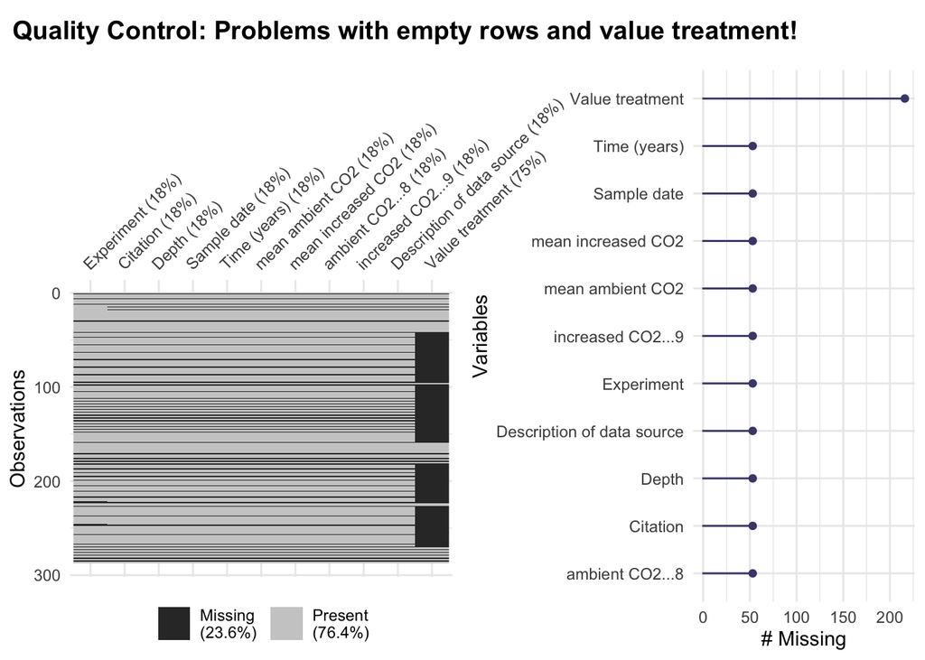

```r
# Change the names of the two columns that are needed later on
raw.data <- raw.data|>
  rename("mean ambient CO2" = `ambient CO2...6`,
         "mean increased CO2" = `increased CO2...7`)

# Load the function
source("../../R/general/function.visualize.na.values.R")

# Function call
visualize.na.values.without.groups(raw.data, c("Problems with empty rows and value treatment!"))
```

## 3.4 Quality Control

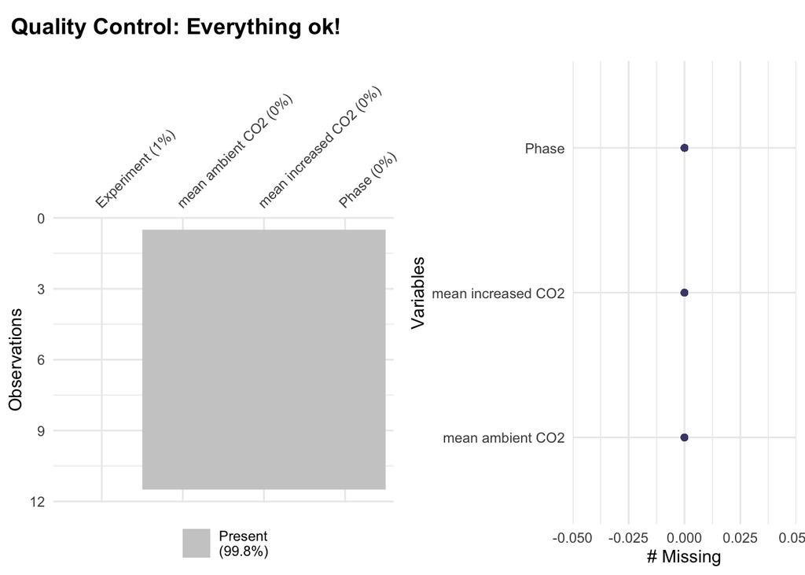

```r
# Load the function to prepare the data set
source("../../R/re_tidy/function.data.preparation.for.LRR.R")

# Function call
DB_S1 <- data.preparation.for.LRR(raw.data)

# Function call
visualize.na.values.without.groups(DB_S1, c("Everything ok!"))
```

## 3.5 LRR calculation for each experiment

Now we calculate the LRR for each experiment and use knitr::kable() for a proper html outcome…

```r
# Load the function to calculate the LRR by experiment
source("../../R/re_tidy/function.LRR.by.experiment.R")

# Function call to calculate the LRR for each experiment and save it as a HTML kable
LRR.by.experiment(DB_S1, 1)
```

Table 1 : LRR for each Experiment

| Experiment | LRR Method 1 | LRR Method 2 |
| --- | --- | --- |
| ArizonaFACE - wheat - high N | 0.004 | 0.004 |
| Biosphere 2 | 0.151 | 0.162 |
| China FACE - high N | -0.093 | -0.093 |
| China FACE - low N | -0.108 | -0.108 |
| China OTC - high N | -0.228 | -0.247 |
| China OTC - low N | -0.012 | -0.021 |
| FACTS I | -0.083 | -0.081 |
| FACTS II - Aspen | 0.086 | 0.081 |
| FACTS II - Aspen (+O3) | 0.190 | 0.181 |
| FACTS II - Aspen/Birch | -0.010 | -0.012 |
| FACTS II - Aspen/Birch (+O3) | 0.012 | 0.011 |
| FACTS II - Aspen/Mapel | -0.052 | -0.052 |
| FACTS II - Aspen/Mapel (+O3) | 0.077 | 0.077 |
| GiFACE | -0.008 | -0.007 |
| Hohenheim | -0.001 | -0.002 |
| JRGCE - Burn | 0.016 | 0.015 |
| JRGCE - Control | 0.063 | 0.064 |
| JRGCE - Heat | -0.011 | -0.010 |
| JRGCE - Heat x N | -0.070 | -0.070 |
| JRGCE - Heat x Water | -0.071 | -0.072 |
| JRGCE - Heat x Water x N | -0.076 | -0.078 |
| JRGCE - N | 0.019 | 0.017 |
| JRGCE - N x Burn | 0.050 | 0.050 |
| JRGCE - Water | 0.056 | 0.057 |
| JRGCE - Water x Burn | -0.015 | -0.014 |
| JRGCE - Water x N | 0.024 | 0.020 |
| JRGCE - Water x N x Burn | -0.100 | -0.099 |
| Jasper Ridge - sandstone | 0.005 | 0.005 |
| Merritt Island | 0.073 | 0.058 |
| New Zealand Greenhouse | -0.009 | -0.009 |
| New Zealand OTC - N. fusca | -0.336 | -0.174 |
| New Zealand OTC - P. radiata | -0.208 | -0.126 |
| NewZealandFACE | 0.024 | 0.025 |
| ORNL FACE | -0.078 | -0.074 |
| POPFACE - alba | 0.145 | 0.146 |
| POPFACE - euramericana | 0.168 | 0.167 |
| POPFACE - nigra | 0.206 | 0.208 |
| Placerville - high N | -0.047 | -0.046 |
| Placerville - low N | 0.009 | 0.007 |
| Placerville - medium N | -0.047 | -0.047 |
| Shortgrass prairie | -0.033 | -0.034 |
| SoyFACE | 0.141 | 0.141 |
| Swiss Greenhouse | 0.095 | 0.103 |
| SwissFACE- clover - high N | -0.077 | -0.075 |
| SwissFACE- clover - low N | -0.063 | -0.064 |
| SwissFACE- grass - high N | -0.008 | -0.004 |
| SwissFACE- grass - low N | -0.037 | -0.037 |
| Tallgrass Prairie | -0.013 | -0.020 |
| UMBS - aspen | -0.085 | -0.091 |
| WSL - loam, high N | -0.023 | -0.022 |
| WSL - loam, low N | -0.058 | -0.055 |
| WSL - sand, high N | -0.026 | -0.027 |
| WSL - sand, low N | -0.019 | -0.020 |
| NA | -0.016 | -0.003 |

## 3.6 LRR calculation for each phase

…and do the same for each phase.

```r
# Load the function to calculate the LRR by phase
source("../../R/re_tidy/function.LRR.by.phase.R")

# Function call to calculate the LRR for each phase and save it as a HTML kable
LRR.by.phase(DB_S1, 2)
```

Table 2 : LRR for each Phase

| Phase | LRR Method 1 | LRR Method 2 |
| --- | --- | --- |
| early | -0.011 | -0.013 |
| mid | -0.023 | -0.017 |
| late | 0.035 | 0.031 |

# 4 Discussion

The result is rounded to 3 digits. As you can see, the results of Method 1 and Method 2 are different. In this case, Method 2 is more meaningful than Method 1 (see theory and method). But this is not always the case. It is therefore important to consider what exactly you want to analyze and what is the context of the experiment.